# Estudo sobre auto-encoders

Fellipe Gomes

5/7/2021

# Dados

```r
train <- read_csv('train.csv')
```

Correlação entre as features

```r
train %>%
  select(-id, -target) %>%
  cor(method = 'spearman') %>%
  heatmaply::heatmaply_cor(
    xlab = "Features",
    ylab = "Features",
    k_col = 4,
    k_row = 8
  )
```

[output not shown]

# Redução de dimensionalidade

## PCA

```r
library("FactoMineR")
library("factoextra")
```

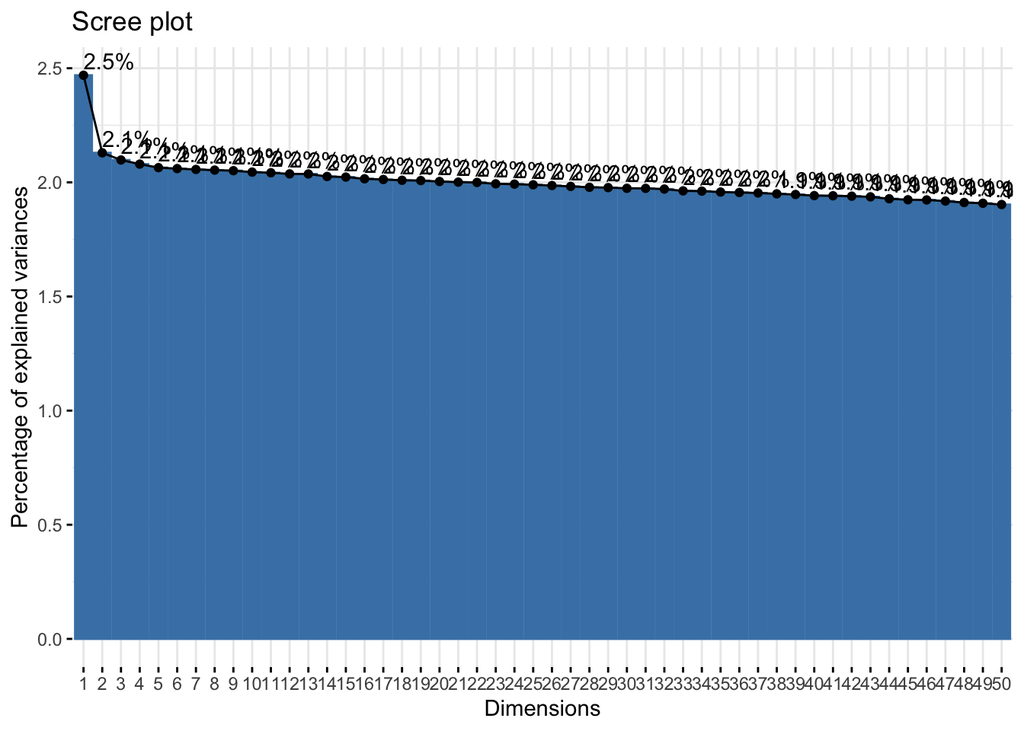

```r
res.pca <-
  train %>%
  select(-id, -target) %>%
  PCA(graph = FALSE, scale.unit = T)

# get_eigenvalue(res.pca)
fviz_eig(res.pca, addlabels = TRUE, ncp = 50)
```

## Auto-Encoder

A ideia básica de um DAE é aprender como o conjunto de dados é construído. Você faz isso adicionando ruído aos seus dados e, em seguida, tenta diminuir o ruído da entrada para que o modelo emita dados limpos.

Se isso for feito da maneira certa, os pesos do seu modelo conterão todas as informações sobre os recursos e suas interações (não há mais necessidade de engenharia de recursos, mas a maior caixa preta que você pode obter!).

#### Bottleneck

```r
library(keras)

normalize <- function(x, na.rm = TRUE) {
    return((x- min(x)) /(max(x)-min(x)))
}

# set training data
x_train <-
  train %>%
  select(-id, -target) %>%
  mutate_all(normalize) %>%
  as.matrix()

# set model
model <- keras_model_sequential()
model %>%
  layer_dense(units = 500, activation = "relu", input_shape = ncol(x_train)) %>%
  layer_dense(units = 500, activation = "relu") %>%
  layer_dense(units = 250, activation = "relu", name = "bottleneck") %>%
  layer_dense(units = 500, activation = "relu") %>%
  layer_dense(units = 500, activation = "relu") %>%
  layer_dense(units = ncol(x_train))

# view model layers
summary(model)
```

```
## Model: "sequential"
## ________________________________________________________________________________
## Layer (type)                        Output Shape                    Param #
## ================================================================================
## dense_4 (Dense)                     (None, 500)                     25500
## ________________________________________________________________________________
## dense_3 (Dense)                     (None, 500)                     250500
## ________________________________________________________________________________
## bottleneck (Dense)                  (None, 250)                     125250
## ________________________________________________________________________________
## dense_2 (Dense)                     (None, 500)                     125500
## ________________________________________________________________________________
## dense_1 (Dense)                     (None, 500)                     250500
## ________________________________________________________________________________
## dense (Dense)                       (None, 50)                      25050
## ================================================================================
## Total params: 802,300
## Trainable params: 802,300
## Non-trainable params: 0
## ________________________________________________________________________________
```

```r
# compile model
model %>% compile(
  loss = "mean_squared_error",
  optimizer = "adam"
)

history <- model %>% fit(
  x_train, x_train,
  epochs = 20, #batch_size = 128,
  view_metrics = TRUE,
  validation_split = 0.2
)
```

```
## starting httpd help server ... done
```

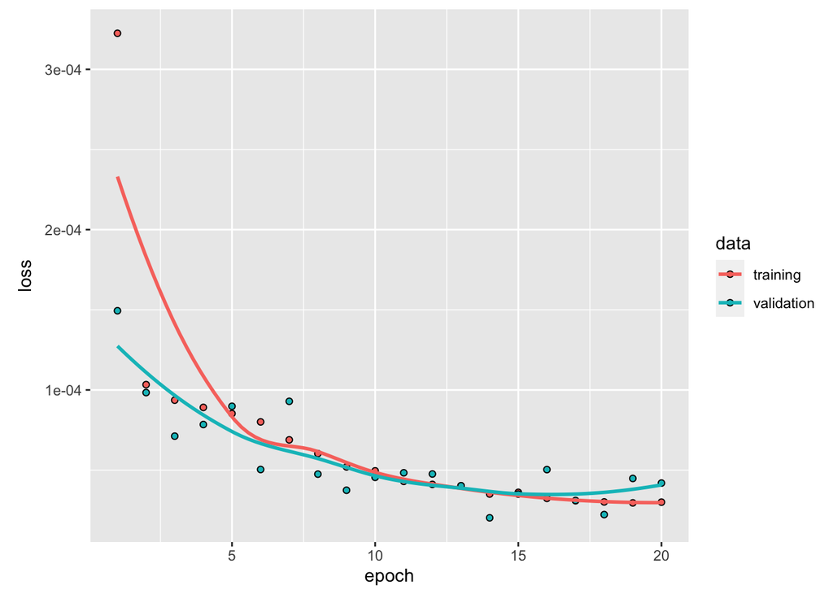

```r
plot(history)
```

```r
# evaluate the performance of the model
mse.ae2 <- evaluate(model, x_train, x_train)
mse.ae2
```

```
##         loss
## 4.153666e-05
```

[figure not shown]

```r
intermediate_layer_model <- keras_model(inputs = model$input, outputs = get_layer(model, "bottleneck")$output)

intermediate_output <- predict(intermediate_layer_model, x_train)

ggplot(data.frame(PC1 = intermediate_output[,1],
                  PC2 = intermediate_output[,2]),
       aes(x = PC1, y = PC2, col = train$target)) +
  geom_point(alpha=.5)
```

```r
train_dae <- predict(model, x_train)
train_dae %>% as_tibble()
```

```
## # A tibble: 100,000 x 50
##           V1        V2       V3        V4        V5         V6       V7       V8
##        <dbl>     <dbl>    <dbl>     <dbl>     <dbl>      <dbl>    <dbl>    <dbl>
##  1  -8.92e-5 -0.00106   0.141    -1.30e-2   3.91e-2   -5.79e-3 -2.21e-3  3.90e-5
##  2   9.03e-5  0.000157 -0.00248  -4.07e-4   5.14e-2    9.58e-2 -1.26e-5 -6.77e-4
##  3  -1.26e-3 -0.00198  -0.00489   3.50e-3   1.04e-2    8.99e-3 -2.42e-3 -8.19e-3
##  4  -4.03e-3  0.000166 -0.00190   3.43e-3  -3.09e-3    1.01e-3 -1.16e-3  7.49e-2
##  5  -8.64e-4 -0.00265   0.00182   1.53e-5   1.82e-3   -1.78e-3  1.14e-3 -9.82e-4
##  6  -7.76e-4 -0.000781 -0.00190   9.15e-4  -2.11e-4    4.69e-4 -5.07e-4 -4.85e-4
##  7   1.99e-2 -0.00347  -0.00630   5.17e-2  -8.04e-5    2.66e-3 -2.88e-3 -3.02e-3
##  8  -5.86e-4 -0.00240  -0.00204   8.52e-2   1.45e-3    5.40e-3  1.09e-1 -2.74e-3
##  9   2.28e-3  0.0324   -0.00400   1.83e-4   8.44e-5   -5.93e-6  3.75e-4  5.22e-4
## 10  -8.96e-5 -0.00113   0.161     1.83e-3  -1.58e-3    1.89e-3 -1.45e-4 -2.82e-3
## # … with 99,990 more rows, and 42 more variables: V9 <dbl>, V10 <dbl>,
## #   V11 <dbl>, V12 <dbl>, V13 <dbl>, V14 <dbl>, V15 <dbl>, V16 <dbl>,
## #   V17 <dbl>, V18 <dbl>, V19 <dbl>, V20 <dbl>, V21 <dbl>, V22 <dbl>,
## #   V23 <dbl>, V24 <dbl>, V25 <dbl>, V26 <dbl>, V27 <dbl>, V28 <dbl>,
## #   V29 <dbl>, V30 <dbl>, V31 <dbl>, V32 <dbl>, V33 <dbl>, V34 <dbl>,
## #   V35 <dbl>, V36 <dbl>, V37 <dbl>, V38 <dbl>, V39 <dbl>, V40 <dbl>,
## #   V41 <dbl>, V42 <dbl>, V43 <dbl>, V44 <dbl>, V45 <dbl>, V46 <dbl>,
## #   V47 <dbl>, V48 <dbl>, V49 <dbl>, V50 <dbl>
```

Autoencoder é uma NN não supervisionada que “aprende” como codificar os dados com eficiência compactando e reconstruindo os dados de volta a partir de uma representação codificada para para que seja o mais proximo possível da entrada original.

Portanto o autoencoder reduz a dimensão dos dados, aprendendo como ignorar o ruído.

4 Componentes do Autoencoder:

1. **Codificador**: Aprende a reduzir as dimensões comprimindo os dados de entrada para uma representao codificada. 2- **Gargalo** : é a camada que contém a representação compactada dos dados de entrada. Esta é a menor dimensão possível dos dados de entrada. 3- **Decodificador** : no qual o modelo aprende como reconstruir os dados a partir da representação codificada para ficar o mais próximo possível da entrada original. 4- **Perda de Reconstrução** : Este é o método que mede o desempenho do decodificador e a proximidade da saída com a entrada original.

O treino envolve *back propagation* para minimizar a função de perda de reconstrução da rede.

1- Autoencoder para detecção de anomalias:

No entanto, se você tiver dados de entrada correlacionados, o método autoencoder funcionará muito bem porque a operação de codificação depende dos recursos correlacionados para compactar os dados.

Digamos que treinamos um codificador automático no conjunto de dados MNIST. Usando uma rede neural FeedForward simples, podemos conseguir isso construindo uma rede simples de 6 camadas como abaixo:

Ver: https://gist.githubusercontent.com/wmlba/ed6448da9dce3a3c0f6ee78e972dd07b/raw/602bb3c79fc4b17334c9d9ba7488e91fbb86b83e/autoencoder_feedforward.py

Observe no código acima, você pode usar apenas a parte do codificador para compactar alguns dados ou imagens e também pode usar apenas a parte do decodificador para descompactar os dados carregando as camadas do decodificador.

Agora, vamos fazer uma detecção de anomalias. O código a seguir usa duas imagens diferentes para prever a pontuação da anomalia (erro de reconstrução) usando a rede autoencoder que treinamos acima. a primeira imagem é do MNIST e o resultado é 5,43209. Isso significa que a imagem não é uma anomalia. A segunda imagem que usei é uma imagem completamente aleatória que não pertence ao conjunto de dados de treinamento e os resultados foram: 6789,4907. Este erro alto significa que a imagem é uma anomalia. O mesmo conceito se aplica a qualquer tipo de conjunto de dados.

Ver: https://gist.githubusercontent.com/wmlba/8a5a8996a14c41e8a1e2de98ca6bfffb/raw/3fbb0a29b596ed45a27e2dcfc9a0ea3f533237ad/predict_anomaly.autoencoder.py

2- Denoising de imagem:

Denoising ou redução de ruído é o processo de remoção de ruído de um sinal. Pode ser uma imagem, áudio ou documento. Você pode treinar uma rede Autoencoder para aprender como remover o ruído das imagens. Para experimentar este caso de uso, vamos reutilizar o famoso conjunto de dados MNIST e criar algum ruído sintético no conjunto de dados. O código a seguir simplesmente adicionará algum ruído ao conjunto de dados e, em seguida, representará algumas imagens para garantir que as tenhamos criado com sucesso.

Ver: https://gist.github.com/wmlba/e01f8a77b98d8836cd6a8c612bbaf389/raw/2aa19a576a3d2804af2898c7f3bb5d39bac3c541/noise_images.py

Neste exemplo, vamos construir uma rede neural autencoder convolucional. Vou percorrer cada linha de construção da rede:

Primeiro, definimos a camada de entrada e as dimensões dos dados de entrada. O conjunto de dados MNIST tem imagens que foram remodeladas para ter dimensões de 28 x 28. Como as imagens são em escala de cinza, o canal de cor da imagem será 1, então a forma é (28, 28, 1).

A segunda camada é a camada de convolução, esta camada cria um kernel de convolução que é convolvido com a entrada da camada para produzir um tensor de saídas. 32 é o número de filtros de saída na convolução e (3, 3) é o tamanho do kernel.

Após cada camada de convolução, usamos a função MaxPooling para reduzir as dimensões. O (28, 28, 32) é reduzido por um fator de dois, então será (14, 14, 32) após o primeiro MaxPooling e (7, 7, 32) após o segundo MaxPooling. Esta é a representação codificada da imagem.

```
input_img = Input(shape=(28, 28, 1))

nn = Conv2D(32, (3, 3), activation='relu', padding='same')(input_img)
nn = MaxPooling2D((2, 2), padding='same')(nn)
nn = Conv2D(32, (3, 3), activation='relu', padding='same')(nn)
encoded = MaxPooling2D((2, 2), padding='same')(nn)
```

O código abaixo é a parte de reconstrução dos dígitos originais. É aqui que a rede realmente aprende como remover o ruído das imagens de entrada. Usamos a função UpSampling para reconstruir as imagens para as dimensões originais (28, 28)

```
nn = Conv2D(32, (3, 3), activation='relu', padding='same')(encoded)
nn = UpSampling2D((2, 2))(nn)
nn = Conv2D(32, (3, 3), activation='relu', padding='same')(nn)
nn = UpSampling2D((2, 2))(nn)
decoded = Conv2D(1, (3, 3), activation='sigmoid', padding='same')(nn)
```

Agora, a última etapa restante é criar o modelo, compilá-lo e iniciar o treinamento. Fazemos isso executando:

```
autoencoder = Model(input_img, decoded)
autoencoder.compile(optimizer='adadelta',loss='binary_crossentropy')
autoencoder.fit(x_train_noisy, x_train,
epochs=50,
batch_size=256,
validation_data=(x_test_noisy, x_test))
```

Referencias:

- https://towardsdatascience.com/auto-encoder-what-is-it-and-what-is-it-used-for-part-1-3e5c6f017726
- http://www.sthda.com/english/articles/31-principal-component-methods-in-r-practical-guide/112-pca-principal-component-analysis-essentials/
- https://www.researchgate.net/post/What-is-the-need-of-auto-encoder-when-we-already-have-powerful-dimension-reduction-techniques-such-as-PCA
- https://www.quora.com/How-is-autoencoder-compared-with-other-dimensionality-reduction-algorithms
- https://www.kaggle.com/c/porto-seguro-safe-driver-prediction/discussion/44629
- https://www.kaggle.com/springmanndaniel/1st-place-turn-your-data-into-daeta